# Data Visualization Project - R

### **3.2.2 Gene expression correlation**

```r
#extracting gene 1 and gene 12 from dataset
gene_data <- data.frame(gene1 = tcga_samples[, 1], gene12 = tcga_samples[, 12])
```

```r
# Calculate Pearson correlation (R)
correlation <- cor(gene_data$gene1, gene_data$gene12, method = "pearson")
```

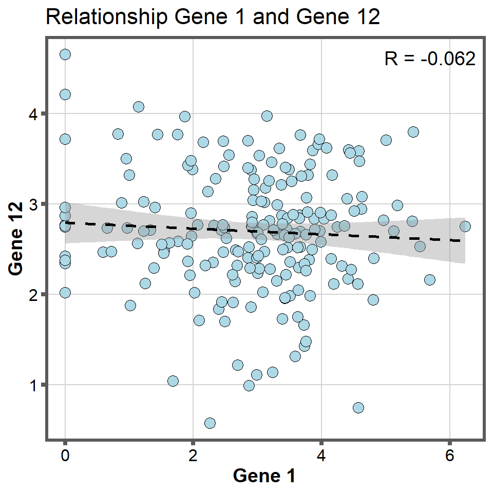

```r
# Create the scatter plot
scatter_plot <- ggplot(data = gene_data, aes(x = gene1, y = gene12)) +
  geom_point(
    color = "black",
    fill = "lightblue",
    shape = 21,
    size = 3.6,
    stroke = 0.50
  ) +
  #Pearson correlation coefficient (R)
  annotate("text", x = Inf, y = Inf, label = paste("R =", round(correlation, 3)),
           hjust = 1.1, vjust = 2, size = 5, color = "black") +
  #add linear line to the plot
  geom_smooth(method = 'lm', color = "black", linetype = "dashed", size = 1, se = TRUE) +
  labs(
    title = "Relationship Gene 1 and Gene 12",
    x = "Gene 1",
    y = "Gene 12"
  ) +
  #customized theme
  theme(
    axis.title = element_text(size = 14, face = "bold"),
    axis.text = element_text(size = 12, color = "black"),
    axis.ticks = element_line(color = "#5A5A5A", linewidth = 1.5),
    panel.grid.major.x = element_line(color = "lightgrey",linewidth = 0.5),
    panel.grid.major.y = element_line(color = "lightgrey",linewidth = 0.5),
    plot.title = element_text(size = 16),
    panel.background = element_rect(fill = "white"),
    panel.border = element_rect(color = "#5A5A5A", fill = NA, size = 2),
  )


scatter_plot
```

Correlation tells how closely two variables are related and whether changes in one variable are associated with changes in the other which is denoted by letter R and it ranges from -1 to 1 . 1 indicate a positive correlation and -1 indicate negative correlation where 0 means no relation

### **3.2.3 Class proportions**

```r
#create a data frame from tcga samples
barchart_data <- tcga_samples_label %>%
  mutate(Class = factor(Class, levels = c("BRCA", "COAD", "KIRC", "LUAD", "PRAD"))) %>%
  group_by(Class) %>%
  #calculate  absolute  frequency for each cancer labels
  summarise(abs_freq = n()) %>%
  # Calculate the percentage of each cancer type and add two column
  mutate(Proportion = abs_freq / 2,
         pos = 1) #finding the proportions from the samples
head(barchart_data)
```

```
## # A tibble: 5 × 4
##   Class abs_freq Proportion   pos
##   <fct>    <int>      <dbl> <dbl>
## 1 BRCA        73       36.5     1
## 2 COAD        14        7       1
## 3 KIRC        34       17       1
## 4 LUAD        40       20       1
## 5 PRAD        39       19.5     1
```

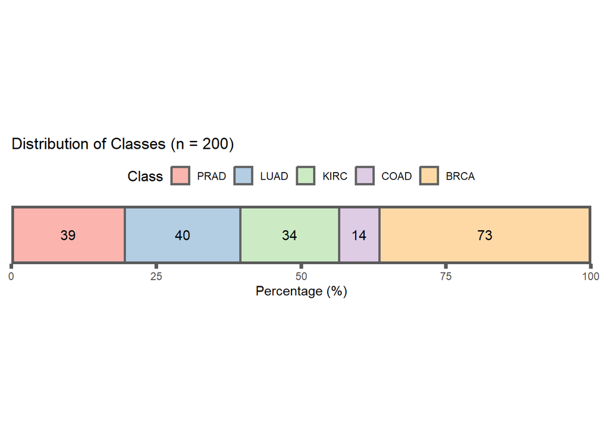

```r
#creating  the Stacked bar charts
propo_plot  <- ggplot(barchart_data, aes(x = pos, y = Proportion, fill = Class)) +
  geom_bar(color = "#636363", linewidth = 1, stat = "identity", width = 0.5) + # use the values already provided (Proportion)
  geom_text(aes(label = abs_freq), position = position_stack(vjust = 0.5), size = 4) +
  labs(
    title = "Distribution of Classes (n = 200)",
    y = "Percentage (%)",
    x = NULL
  ) +
  theme_minimal() +
  theme(
     # Adjust plot margins
    axis.ticks =  element_line(color = "#5A5A5A",linewidth = 1.5),
    axis.ticks.length = unit(.15, "cm"),
    axis.text.y = element_blank(),
    axis.ticks.y = element_blank(),
    plot.margin = unit(c(1.5, 15, 1.5, 5.5), "points"),
    panel.border = element_rect(color = "#5A5A5A", fill = NA, size = 2),
    legend.title = element_text(size = 12),
    legend.position = "top",
  ) +

  coord_flip() +  # Flip coordinates for  horizontal bars
  scale_x_continuous(expand = c(0, 0), limits = c(0.75, 1.25)) +
  scale_y_continuous(expand = c(0, 0)) +
  theme(aspect.ratio = .1) +
  #Use a custom color palette for the bar chart
  scale_fill_discrete(breaks = c("PRAD","LUAD", "KIRC", "COAD", "BRCA"),
                      #pastel 1 reversed order
                      type = rev(RColorBrewer::brewer.pal(5, "Pastel1")))

propo_plot
```

The color which chosen is a good choice for visualizing the distribution of classes.It helps in

differentiating between each class. Even though I think using a more varied color palette with

higher contrast and are color blind friendly like “cbPalette” would be a better color choice than this

### **3.2.4 Combine the plots**

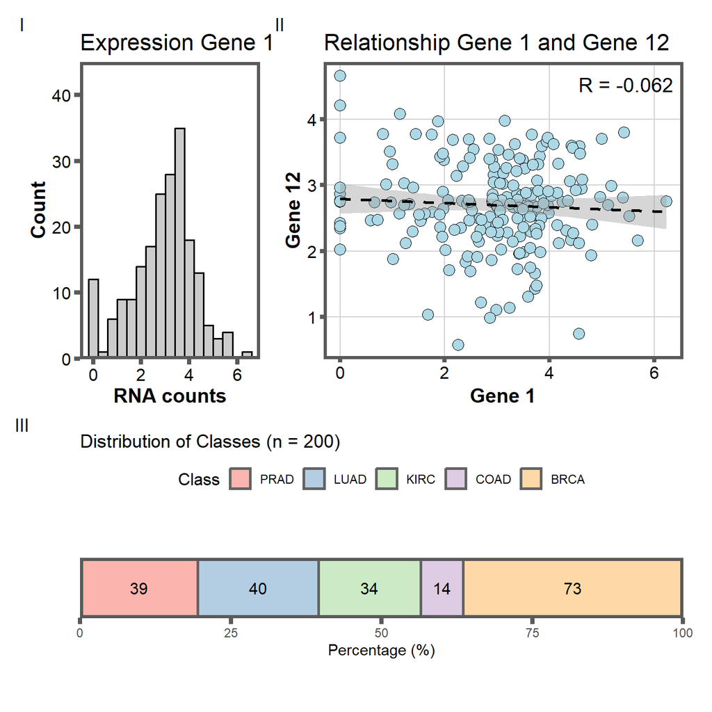

```r
# Combine gene expression histogram plot and correlation plot side-by-side in the upper panel
upper <- (histo1 | scatter_plot) + plot_layout(widths = c(1, 2))

# Combine the upper panel with propo_plot in a vertical stack
final_plot <- (upper / propo_plot) +
  plot_layout(heights = c(2, 1)) + # Adjust height ratio
  plot_annotation(tag_levels = 'I') # Add tags


final_plot
```

## **4 Human genome**

```r
#loading data
hg38_gene <- readr::read_tsv("C:/Users/abrup/OneDrive/Desktop/LSI-2/Data_Vis_final_project//Data_Vis_R/hg38_genes.tsv")
hg38_gene <- as.data.frame(hg38_gene)
head(hg38_gene)
```

```
##     chr start_gene  end_gene strand_gene       gene_name      ensembl_id
## 1 chr19   35414881  35415149           -       RN7SL491P ENSG00000264400
## 2 chr15   27621534  27629289           + ENSG00000258594 ENSG00000258594
## 3  chr2   95477008  95484754           -         TRIM43B ENSG00000144010
## 4 chr15   96354237  96405235           + ENSG00000259275 ENSG00000259275
## 5 chr16   27313668  27364778           +            IL4R ENSG00000077238
## 6  chr6  128928995 128929988           -          MESTP1 ENSG00000220884
##              gene_type
## 1             misc_RNA
## 2               lncRNA
## 3       protein_coding
## 4               lncRNA
## 5       protein_coding
## 6 processed_pseudogene
```

```r
#filtering data based on gene type
hg38_fil<- filter(hg38_gene, gene_type %in% c("protein_coding", "lncRNA", "processed_pseudogene", "transcribed_unprocessed_pseudogene"))
head(hg38_fil)
```

```
##     chr start_gene  end_gene strand_gene       gene_name      ensembl_id
## 1 chr15   27621534  27629289           + ENSG00000258594 ENSG00000258594
## 2  chr2   95477008  95484754           -         TRIM43B ENSG00000144010
## 3 chr15   96354237  96405235           + ENSG00000259275 ENSG00000259275
## 4 chr16   27313668  27364778           +            IL4R ENSG00000077238
## 5  chr6  128928995 128929988           -          MESTP1 ENSG00000220884
## 6  chr1   22028317  22052927           -       CDC42-AS1 ENSG00000285752
##              gene_type
## 1               lncRNA
## 2       protein_coding
## 3               lncRNA
## 4       protein_coding
## 5 processed_pseudogene
## 6               lncRNA
```

```r
# Rename and group the gene types
hg38_fil <- hg38_fil %>%
  mutate(
    gene_type = case_when(
      gene_type == "protein_coding" ~ "mRNA",
      gene_type %in% c("processed_pseudogene", "transcribed_unprocessed_pseudogene") ~ "Pseudo",
      TRUE ~ gene_type
    )
  )
# Calculate gene length and filter
hg38<- hg38_fil %>%
  mutate(gene_length =  end_gene - start_gene) %>%
  filter(gene_length > 1000 & gene_length <= 20000)

# View the final dataframe
head(hg38)
```

```
##     chr start_gene  end_gene strand_gene       gene_name      ensembl_id
## 1 chr15   27621534  27629289           + ENSG00000258594 ENSG00000258594
## 2  chr2   95477008  95484754           -         TRIM43B ENSG00000144010
## 3 chr19   15571762  15573650           + ENSG00000290595 ENSG00000290595
## 4  chr1  157925065 157929862           + ENSG00000236957 ENSG00000236957
## 5  chr5  180826871 180831621           -            HEIH ENSG00000278970
## 6  chrY    2609415   2623453           +          CD99P1 ENSG00000292361
##   gene_type gene_length
## 1    lncRNA        7755
## 2      mRNA        7746
## 3    lncRNA        1888
## 4    Pseudo        4797
## 5    lncRNA        4750
## 6    Pseudo       14038
```

### **4.2 Plotting**

### **4.2.1 Gene count**

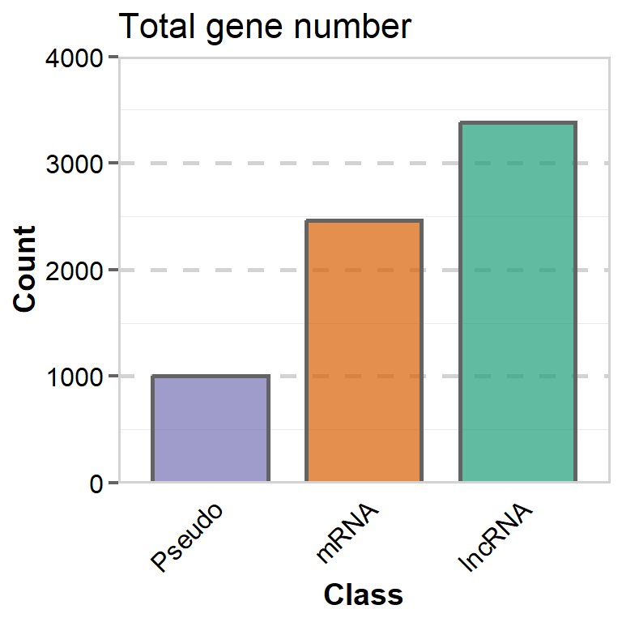

```r
gene_plot <- ggplot(hg38,aes(gene_type))+
  labs(title = "Total gene number" , x = "Class", y = "Count")+
  theme_minimal() +
  #custommize theme
  theme(
    axis.ticks.length = unit(0.15, "cm"),
    axis.title = element_text(size = 14, face = "bold"),
    axis.text = element_text(size = 12, color = "black"),
    axis.text.x = element_text(size = 12, color = "black", angle = 45, hjust = 1),
    axis.ticks.y = element_line(color = "#636363", linewidth = 0.75),
    axis.ticks.x = element_blank(),
    plot.title = element_text(size = 16),
    panel.background = element_rect(fill = "white"),
    panel.grid.major.x = element_blank(),
    panel.grid.major.y = element_line(color = "lightgrey", linewidth = 1, linetype = "dashed"),
    panel.border = element_rect(color = "lightgrey", fill = NA, size = 1)
  ) +
  geom_bar(aes(fill = gene_type), color= "#636363", linewidth= 1,  width = 0.75,
           show.legend = F, alpha = 0.7) +
  scale_y_continuous(expand = c(0,0), limits = c(0, 4000))+
  scale_fill_discrete(type = brewer.pal(3, "Dark2"))+
  scale_x_discrete(limits = c("Pseudo", "mRNA", "lncRNA"))
print(gene_plot)
```

### **4.2.2 Length distribution**

```r
# Calculate median gene length for each gene_type
hg38_sel <- hg38 %>%
  mutate(gene_length = end_gene - start_gene)

median_gene_lengths <- hg38_sel%>%
  mutate(gene_length = end_gene - start_gene) %>% # Add gene_length column
  group_by(gene_type) %>%
  summarise(median_length = median(gene_length)) # Calculate median

print(median_gene_lengths)
```

```
## # A tibble: 3 × 2
##   gene_type median_length
##   <chr>             <dbl>
## 1 Pseudo             1547
## 2 lncRNA             4438
## 3 mRNA               8251
```

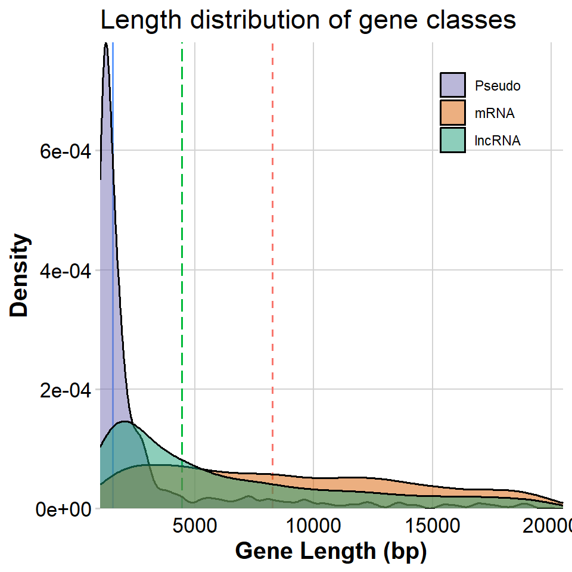

```r
# Extract the median values for each gene type
me_pseudo <- median_gene_lengths$median_length[median_gene_lengths$gene_type == "Pseudo"]
me_mRNA <- median_gene_lengths$median_length[median_gene_lengths$gene_type == "mRNA"]
me_lncRNA <- median_gene_lengths$median_length[median_gene_lengths$gene_type == "lncRNA"]

# Create a density plot to visualize the gene length distribution for each gene type
density_plot<- ggplot(hg38_sel, aes(x=gene_length, fill = fct_rev(gene_type))) +
  #add vertical line based on each gene's type
  geom_vline(data = median_gene_lengths, aes(xintercept = me_pseudo, color = "#D95F02"),
             linewidth = 0.7, show.legend = F) +
  geom_vline(data = median_gene_lengths, aes(xintercept = me_mRNA, color = "#1B9E77"),
             linetype = "dashed", linewidth = 0.7, show.legend = F) +
  geom_vline(data = median_gene_lengths, aes(xintercept = me_lncRNA, color = "#7570B3"),
             linetype = "longdash", linewidth = 0.7, show.legend = F) +
  geom_density(color = "black", alpha = 0.5, linewidth = 0.7) +
  #manuely fill colors
  scale_fill_manual(values = c("Pseudo" = "#7570B3", "mRNA" = "#D95F02", "lncRNA" = "#1B9E77"))+
  scale_y_continuous(expand = c(0,0))+
  scale_x_continuous(expand = c(0,0), limits = c(1000,20500))+
  labs(title = "Length distribution of gene classes",
       x = "Gene Length (bp)", y = "Density") +
  theme(
    axis.title = element_text(size = 15, face = "bold"),
    axis.text = element_text(size = 13, color = "black"),
    axis.ticks.x =  element_blank(),
    axis.ticks.y = element_line(color = "lightgrey",linewidth = 0.7),
    plot.title = element_text(size = 17),
    panel.grid.minor = element_blank(),
    panel.border = element_blank(),
    panel.background = element_rect(fill = "white"),
    panel.grid.major.x = element_line(color = "lightgrey" ,linewidth = 0.5),
    panel.grid.major.y =  element_line(color = "lightgrey" ,linewidth = 0.5),
    legend.position= c(0.82, 0.85),
    legend.title=element_blank(),
    legend.background = element_rect(fill='transparent'),
    legend.box.background = element_blank(),
  )

# Display the plot
print(density_plot)
```

An alternative approach for overlapping density plot is Box plot and Violin Plot . In box plot it show both median ,spread of data and also any outliers. Violin plot is also a better option which shows the information like box plot and in addition it shows how densely the data points are packed together for different lengths.

Below I have drawn both box and violin plot

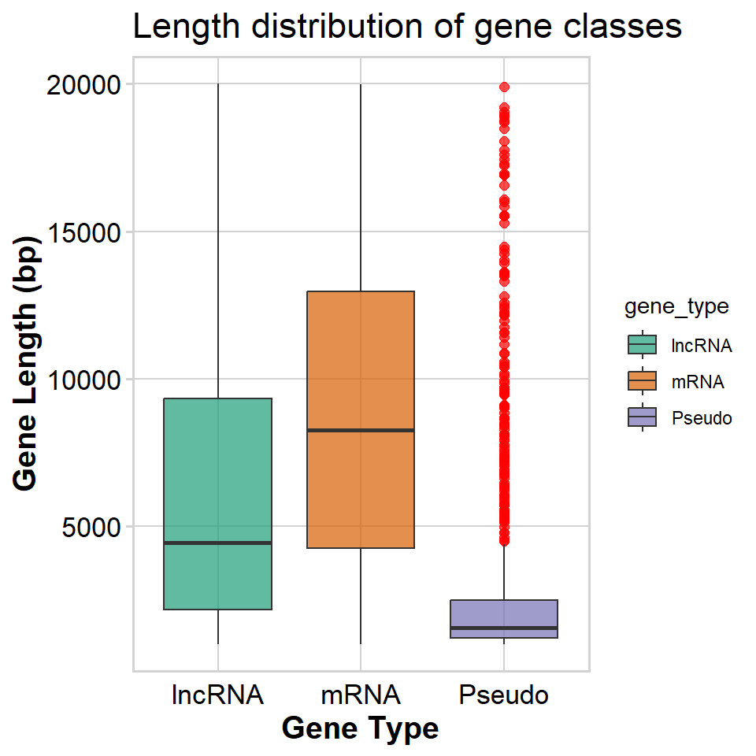

```r
#box plot
box_plot<- ggplot(hg38_sel, aes(x=gene_type, y=gene_length, fill = gene_type)) +
  geom_boxplot(outlier.size = 2, outlier.colour = "red", alpha = 0.7) +
  scale_fill_manual(values = c("Pseudo" = "#7570B3", "mRNA" = "#D95F02", "lncRNA" = "#1B9E77")) +
  labs(title = "Length distribution of gene classes",
       x = "Gene Type", y = "Gene Length (bp)") +
  theme(
    panel.grid.minor = element_blank(),
    panel.background = element_rect(fill = "white"),
    panel.grid.major.x = element_line(color = "lightgrey" ,linewidth = 0.5),
    panel.grid.major.y =  element_line(color = "lightgrey" ,linewidth = 0.5),
    plot.title = element_text(size = 17),
    axis.title = element_text(size = 15, face = "bold"),
    axis.text = element_text(size = 13, color = "black"),
    axis.ticks.x =  element_blank(),
    axis.ticks.y = element_line(color = "lightgrey",linewidth = 0.7),
    panel.border = element_rect(color = "lightgrey", fill = NA, size = 1),
  )

# Display the boxplot
print(box_plot)
```

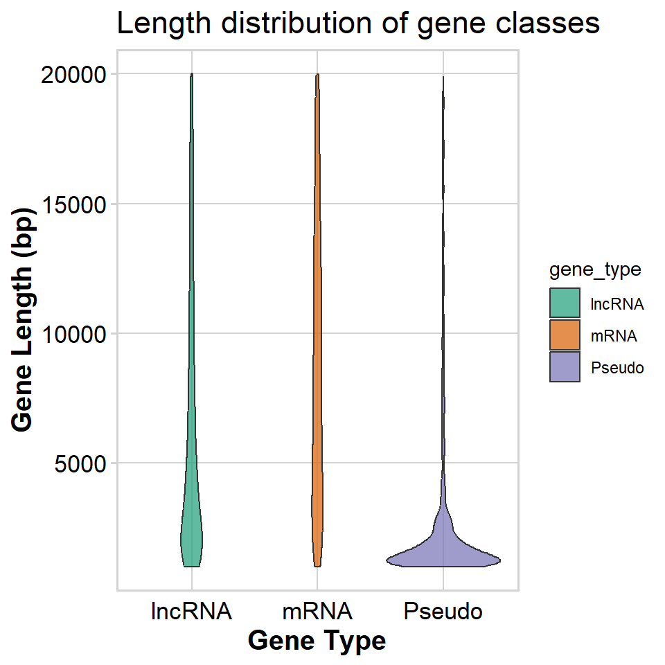

```r
#violin plot
violin_plot <- ggplot(hg38_sel, aes(x=gene_type, y=gene_length, fill = gene_type)) +
  geom_violin(alpha = 0.7) +
  scale_fill_manual(values = c("Pseudo" = "#7570B3", "mRNA" = "#D95F02", "lncRNA" = "#1B9E77")) +
  labs(title = "Length distribution of gene classes",
       x = "Gene Type", y = "Gene Length (bp)") +
  theme(
    panel.grid.minor = element_blank(),
    panel.background = element_rect(fill = "white"),
    panel.grid.major.x = element_line(color = "lightgrey", linewidth = 0.5),
    panel.grid.major.y =  element_line(color = "lightgrey", linewidth = 0.5),
    plot.title = element_text(size = 17),
    axis.title = element_text(size = 15, face = "bold"),
    axis.text = element_text(size = 13, color = "black"),
    axis.ticks.x =  element_blank(),
    axis.ticks.y = element_line(color = "lightgrey", linewidth = 0.7),
    panel.border = element_rect(color = "lightgrey", fill = NA, size = 1),
  )

# Display the violin plot
print(violin_plot)
```

### **4.2.3 Include figure**

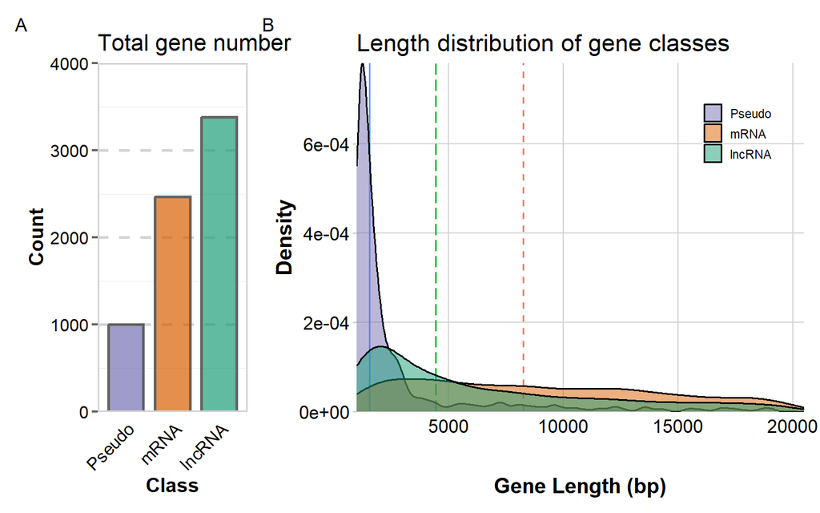

```r
# Define the additional theme for adjusting the legend position
combined_plots <- density_plot + theme(legend.position = c(0.85, 0.8),
    legend.key.size = unit(0.5, 'cm'))

# Combine the two plots side by side
combined_plot2 <- gene_plot + combined_plots +
  plot_layout(widths = c(1, 3)) +  # Adjust relative widths of the plots
  plot_annotation(tag_levels = 'A')  # Add plot annotation tags

# Display the combined plot
combined_plot2
```

## **5 Differntial gene Expression**

### **5.1 load and prepare data**

```r
# Read the data
deseq_data <- read.delim("C:/Users/abrup/OneDrive/Desktop/LSI-2/Data_Vis_final_project/Data_Vis_R/deseq2_dummy.txt", header = TRUE, sep = "\t")
```

```r
# Select the top 2000 genes according to the average of the normalized count values
top_2000_genes <- deseq_data %>%
  #sorting
  arrange(desc(baseMean)) %>%
  slice(1:2000) %>%
  #modify based on the given values
  mutate(
    significant = case_when(
      log2FoldChange > 0 & padj < 0.1 ~ "up",
      log2FoldChange < 0 & padj < 0.1 ~ "down",
      TRUE ~ "n.s"
    ),
    label = ifelse(padj < 0.1 & log2FoldChange > 2, gene_id, NA)
  )
```

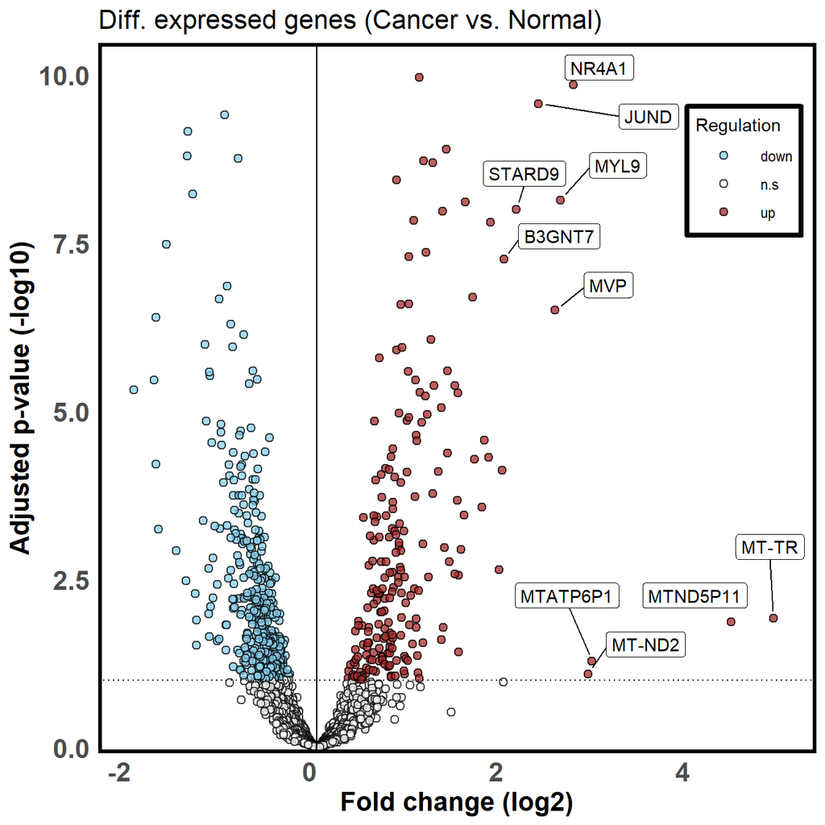

```r
# Create the volcano plot
volcano_plot <- ggplot(top_2000_genes, aes(x = log2FoldChange, y = -log10(padj))) +
  geom_point(aes(fill = significant), shape = 21, size = 2, alpha = .75, stroke = 0.75) +
  scale_fill_manual(values = c("up" = "brown", "down" = "skyblue", "n.s" = "white")) +
  labs(
    title = "Diff. expressed genes (Cancer vs. Normal)",
    x = "Fold change (log2)",
    y = "Adjusted p-value (-log10)",
    fill = "Regulation"
  ) +
  theme_minimal() +
  geom_label_repel(
    aes(label = label),
    nudge_y = 0.5,
    nudge_x = 0.5,
    box.padding = 0.5,
    point.padding = 0.5,
    na.rm = TRUE,
    max.overlaps = Inf
  ) +
  # adding vertical and horizontal line
  geom_vline(xintercept = 0, linewidth = 0.5) +
  geom_hline(yintercept = 1, linetype = "dotted", linewidth = 0.5) +
  #Customizing the coordinate system
  coord_cartesian(xlim = c(-2, 5), ylim = c(0.4, 10), expand = TRUE) +
  theme(
    plot.title = element_text(size = 16),
    axis.title = element_text(face = "bold", size = 16),
    axis.text = element_text(size = 16, face = "bold", hjust = 1),
    panel.grid.major.y = element_blank(),
    panel.grid.minor.x = element_blank(),
    panel.grid.major.x = element_blank(),
    panel.grid.minor.y = element_blank(),
    panel.border = element_rect(linewidth = 2, fill = NA),
    legend.position = c(0.9, 0.82),
    legend.box.background = element_rect(color = "black", fill = NA, linewidth = 1.5),
    legend.key.width = unit(1.2, "cm")
  )

# Display the volcano plot
volcano_plot
```

### **5.2.2 Heatmaps**

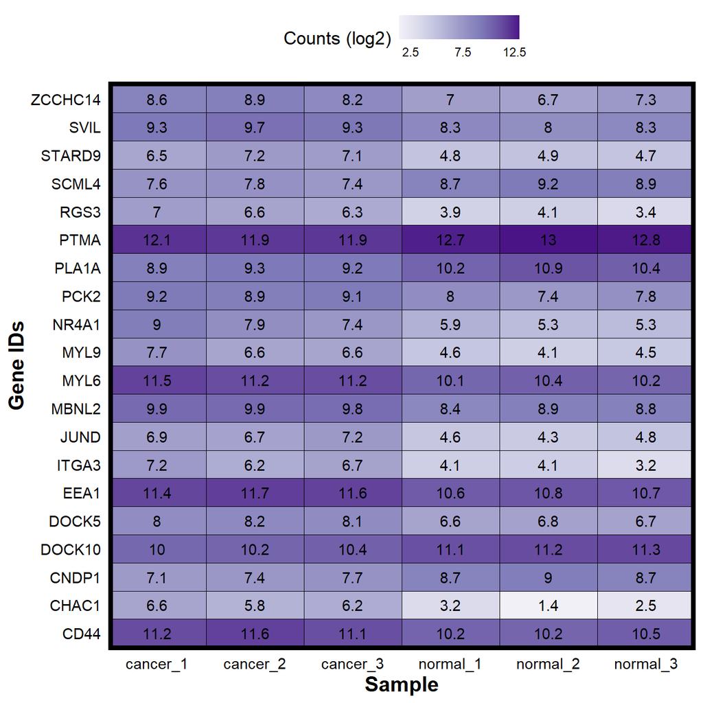

```r
# Filter the top 20 genes based on adjusted p-value
deseq2_res_f <- deseq_data %>%
  slice_min(n = 20, order_by = padj)

# Create the plot
deseq2_res_f %>%
  dplyr::select(gene_id, 9:14) %>%
  pivot_longer(cols = 2:7, names_to = "condition", values_to = "counts") %>%
  ggplot(aes(x = condition, y = gene_id, fill = log2(counts), label = round(log2(counts), digits = 1))) +
  geom_tile(color = "black") +
  geom_text(color = "black") +
  coord_cartesian(ylim = c(0.4, 20.6), expand = FALSE) +
  scale_fill_distiller(breaks = c(2.5, 7.5, 12.5), palette = "Purples", direction = 1) +
  labs(x = "Sample", y = "Gene IDs", fill = "Counts (log2)") +
  theme_minimal() +
  theme(
    legend.position = "top",
    legend.ticks = element_blank(),
    title = element_text(size = 13),
    axis.text = element_text(size = 11, colour = "black"),
    axis.title = element_text(size = 15, face = "bold"),
    panel.border = element_rect(size = 3, fill = NA)
  )
```